# 11082245_BIOL63101_Assignment2

11082245

2022-12-15

# Before Reading

The R script, R Markdown and this `.html` file were uploaded to [my GitHub repository](https://github.com/azanghai/UoM_BIOL63101_Assignment_2), where you can view or download my code. I have also uploaded the .html file to my website. You can click here to view. In order to make the code look neater, the code already explained in the text will not be explained again.

**To get the best browsing experience, maximize the browser.**

**You can use the switch button on the left if you want to switch to a different colour theme.**

# Before start

Before starting the analysis, we want to load our packages first.

```r
# load tidyverse for reading, wrangling and plotting data
library(tidyverse)
# load afex for ANOVA functions
library(afex)
# load emmeans for pairwise comparisons
library(emmeans)
# load psych for data summarize
library(psych)
# load skimr package for data summarize
library(skimr)
# load ggpubr package for plotting
library(ggpubr)
# load car package for leveneTest
library(car)
```

# Question 1

## Load Data and Preliminary Processing

Here, by using function `read_csv()` function in `tidyverse` package, we load `.csv` file as a dataframe in RStudio.

```r
#load data
Q1_data = read_csv('./Raw_Data/assignment_2_dataset_1.csv')
# check if the data is correctly loaded
head(Q1_data)
```

```
## # A tibble: 6 × 3
##   participant condition   response_time
##         <dbl> <chr>               <dbl>
## 1           1 condition_a          984.
## 2           2 condition_a         1005.
## 3           3 condition_a          979.
## 4           4 condition_a         1040.
## 5           5 condition_a         1008.
## 6           6 condition_a          979.
```

We find that: * value from condition needs to be renamed for better understanding. * column `condition` needs to be converted to factor.

```r
# rename the value from condition_a, condition_b to normally and degraded.
# here we use mutate() function to recreate the column.
# case_when() is to select case that fits for different "condition".
Q1_data = Q1_data %>%
    mutate(
    condition = case_when(
      condition == "condition_a" ~ "normally",
      condition == "condition_b" ~ "degraded"
    )
  )

# code condition as a factor,using mutate function and factor function to replace the old column.
Q1_data = Q1_data %>%
    mutate(condition = factor(condition))

# double check if the data is coded correctly.
head(Q1_data)
```

```
## # A tibble: 6 × 3
##   participant condition response_time
##         <dbl> <fct>             <dbl>
## 1           1 normally           984.
## 2           2 normally          1005.
## 3           3 normally           979.
## 4           4 normally          1040.
## 5           5 normally          1008.
## 6           6 normally           979.
```

Now the data looks correctly loaded.

## Summarize the Data

Here I have use different measures to summarize the data, the result is the same, but the method provide different aspect of the data.

### Using Base R Functions

We can use base R functions to summarize the data by using following code.

```r
# summarize data using base R functions
Q1_data %>%
    # we want to view the data in different conditions.
    group_by(condition) %>%
    # here we calculate mean and sd for the data, using summarize()
    summarise(mean = mean(response_time), sd = sd(response_time))
```

```
## # A tibble: 2 × 3
##   condition  mean    sd
##   <fct>     <dbl> <dbl>
## 1 degraded  1020.  23.5
## 2 normally  1002.  21.0
```

### Using `psych` Package

`psych` is a package specifically coded for psychology students. It has most function for personality, psychometric theory and experimental psychology purpose. Here we use `describeBy()` function to summarize the data. The reason I use this package is because it provide values from the number of valid cases to the skew, which gives us a good understanding of the data.

```r
# according to the documentation of this package, to compare data in different groups, we use `describeBy()` function.
# The first argument sent is the data frame, and the second one is the group list.
describeBy(Q1_data$response_time, Q1_data$condition)
```

```
##
##  Descriptive statistics by group
## group: degraded
##    vars  n   mean    sd median trimmed   mad    min     max  range skew
## X1    1 48 1020.3 23.53 1020.7 1019.85 23.13 969.88 1075.04 105.16 0.18
##    kurtosis  se
## X1    -0.33 3.4
## ------------------------------------------------------------
## group: normally
##    vars  n    mean    sd  median trimmed   mad    min     max range  skew
## X1    1 48 1002.22 21.01 1003.23 1003.57 20.61 944.63 1039.88 95.25 -0.62
##    kurtosis   se
## X1     0.21 3.03
```

### Using `skimr` Package

`skimr` is also a package that helps us summarize the data , the reason I use this package is that it can compare the data in one chart. And it’s also easy to use.

```r
Q1_data %>%
    group_by(condition) %>%
    # here we use skim() function to generate summarize.
    skim() %>%
    # as we are only interested in the response_time variable, we use filter() to select it and compare between groups.
    filter(skim_variable == "response_time")
```

Data summary

| Name | Piped data |
| --- | --- |
| Number of rows | 96 |
| Number of columns | 3 |
| _______________________ |  |
| Column type frequency: |  |
| numeric | 1 |
| ________________________ |  |
| Group variables | condition |

**Variable type: numeric**

| skim_variable | condition | n_missing | complete_rate | mean | sd | p0 | p25 | p50 | p75 | p100 | hist |
| --- | --- | --- | --- | --- | --- | --- | --- | --- | --- | --- | --- |
| response_time | degraded | 0 | 1 | 1020.30 | 23.53 | 969.88 | 1003.30 | 1020.70 | 1032.31 | 1075.04 | ▂▅▇▃▂ |
| response_time | normally | 0 | 1 | 1002.22 | 21.01 | 944.63 | 990.01 | 1003.23 | 1017.68 | 1039.88 | ▁▂▇▇▃ |

## Data Visualization

Here, by visualizing the data, we can have a first impression of whether there are differences in the data.

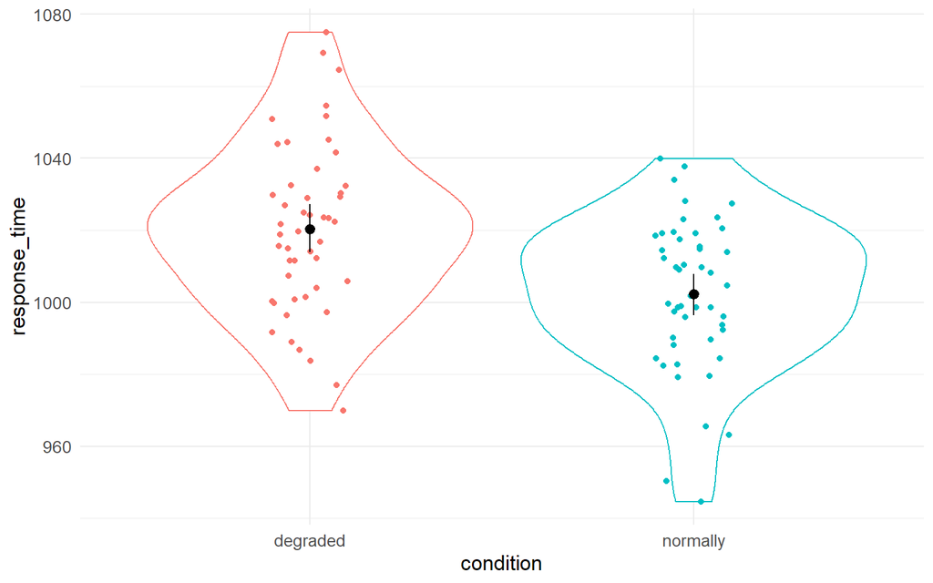

```r
# Seed is set here to ensure reproducibility.
set.seed(11082245)
# use ggplot to demonstrate the distribution of data.
Q1_data %>%
    #here we set x axis as condition, y axis as response time, and We coloured the data according to the different conditions.
    ggplot(aes(x = condition, y = response_time, colour = condition)) +
    # here we add a layer of violin plot using settings and parameters in ggplot()
    geom_violin() +
    # let the dots jitter a little bit to have a better look.
    geom_jitter(width = .1) +
    # the figure is clear enough and we do not need a guides.
    guides(colour = FALSE) +
    # here we use stat_summary() function to add another layer.
    # "mean_cl_boot" is a built in function to acquire confidence limits for the mean.
    stat_summary(fun.data = "mean_cl_boot", colour = "black") +
    # also, a theme and text size is set here for a better view.
    theme_minimal() +
    theme(text = element_text(size = 13))
```

## Normality and Homogeneity of Variance Test

As there are three assumptions in ANOVA.  
- The responses for each factor level have a normal population distribution.  
- These distributions have the same variance.  
- The data are independent.

Though the program will calculate and correct the variance, and The central limit theorem tells us that no matter what distribution things have, the sampling distribution tends to be normal if the sample is large enough (n > 30). Still, we would like to perform a test for Normal Distribution and Homogeneity of Variance

### Normality Test

#### Q-Q plot

We can draw a Q-Q plot to find whether the data is distributed normally.

As we can see, if the dots is distributed around the line `y = x`, it means that the distribution of the data is likely to be Normal distribution. But to be certain, we also need to perform a Normal Distribution Test

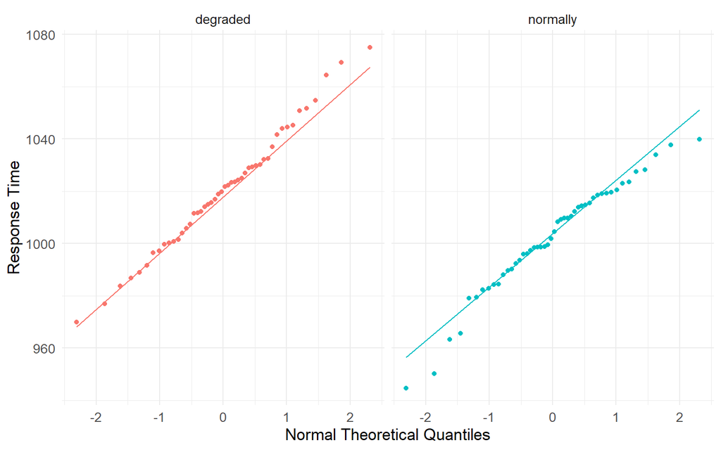

```r
ggplot(data = Q1_data, aes(sample = response_time, colour = factor(condition))) +
  geom_qq() +
  geom_qq_line() +
  facet_wrap(~condition) +
  guides(colour = FALSE) +
  labs(y = "Response Time", x = "Normal Theoretical Quantiles") +
  theme_minimal() +
  theme(text = element_text(size = 13))
```

From the plot, we can see that the dots for different data group is closely attached to the `y = x` line. Therefore, the data may be normally distributed.

#### Shapiro-Wilk Normality Test

Then we perform a Shapiro-Wilk normality test.

```r
# here we use tapply()function, the first argument is the data frame, the second argument is the Classification parameters, the third one is the function that we want to perform, this function allows us to perform multiple repeated functions by using one line of code.
tapply(Q1_data$response_time,Q1_data$condition,shapiro.test)
```

```
## $degraded
##
##  Shapiro-Wilk normality test
##
## data:  X[[i]]
## W = 0.9911, p-value = 0.9727
##
##
## $normally
##
##  Shapiro-Wilk normality test
##
## data:  X[[i]]
## W = 0.96558, p-value = 0.1695
```

For the output, the P-value > 0.05. Therefore we could say that the distribution of the data are not significantly different from normal distribution. In other words, we can assume the normality.

### Homogeneity of Variance Test

Here we perform a Levene’s Test for Homogeneity of Variance. Only because this is one of the most commonly used method.

```r
# this function is in car package which is loaded by the tidyverse. Just like the liner model, we load the factor and the variable in the function to get a result
leveneTest(response_time ~ condition, data = Q1_data)
```

```
## Levene's Test for Homogeneity of Variance (center = median)
##       Df F value Pr(>F)
## group  1  0.4219 0.5176
##       94
```

As the p-value is higher than 0.05(0.5175), Therefore we accept the null hypothesis (H0): the variances of the two groups are equal.

## Building ANOVA model

Here, we build the model by considering `response_time` as DV, and `condition` as IV. Meanwhile, `participant` is considered as the souce of random error.

```r
Q1_model_1 = aov_4(response_time ~ condition + (1 | participant),data = Q1_data)
```

```
## Contrasts set to contr.sum for the following variables: condition
```

Then, we would like to take a look at the model we built, and perform a post-hoc analysis.

```r
summary(Q1_model_1)
```

```
## Anova Table (Type 3 tests)
##
## Response: response_time
##           num Df den Df    MSE      F     ges    Pr(>F)
## condition      1     94 497.58 15.781 0.14375 0.0001393 ***
## ---
## Signif. codes:  0 '***' 0.001 '**' 0.01 '*' 0.05 '.' 0.1 ' ' 1
```

```r
# by using emmeans(), we could compare the data group by the condition factor.
emmeans(Q1_model_1, pairwise~condition)
```

```
## $emmeans
##  condition emmean   SE df lower.CL upper.CL
##  degraded    1020 3.22 94     1014     1027
##  normally    1002 3.22 94      996     1009
##
## Confidence level used: 0.95
##
## $contrasts
##  contrast            estimate   SE df t.ratio p.value
##  degraded - normally     18.1 4.55 94   3.973  0.0001
```

we can also view the result in a plot by adding sever layer on the plot we have made. Function `stat_compare_means()` is used to accomplish this task. By setting `comparisons` to `degraded` and `normally`, we draw a line to indicate the p-value between these groups. Also, by setting `symnum.args`, we can convert p-value to symbols for a better understanding.

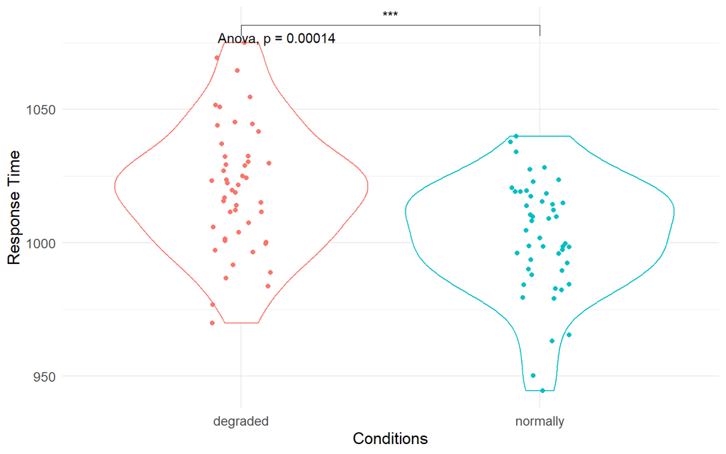

```r
Q1_data %>%
    ggplot(aes(x = condition, y = response_time, colour = condition)) +
    geom_violin() +
    geom_jitter(width = .1) +
    # here we add ANOVA result to the plot
    stat_compare_means(method = "anova") +
    # here we draw the line to compare groups
    stat_compare_means(comparisons = list(c("degraded", "normally")),symnum.args = list(
        # use * to illustrate the p value
        cutpoints = c(0, 0.0001, 0.001, 0.01, 0.05, Inf),
        symbols = c("****", "***", "**", "*", "ns")
    )) +
    guides(colour = FALSE)+
    theme_minimal() +
    theme(text = element_text(size = 13))+
    labs(y = "Response Time", x = "Conditions")
```

### T-test

As the experiment is a between participants design, and only have a factor with 2 levels. Therefore, a t-test is available for the data analysis.

```r
# by using built in t.test() function, the first parameter we sent is the data frame, and the second one is group value, the function will perform a t-test based on the parameter we sent.
t.test(Q1_data$response_time ~ Q1_data$condition)
```

```
##
##  Welch Two Sample t-test
##
## data:  Q1_data$response_time by Q1_data$condition
## t = 3.9726, df = 92.825, p-value = 0.0001404
## alternative hypothesis: true difference in means between group degraded and group normally is not equal to 0
## 95 percent confidence interval:
##   9.046027 27.130330
## sample estimates:
## mean in group degraded mean in group normally
##               1020.304               1002.215
```

The result is similar, difference is significant.

## Conclusion

From the analysis performed. It can be inferred that the difference between response time caused by different visual quality is significant. Which means, the subject will response quicker(estimated marginal means = 1002) with normally present the words than visually degraded(estimated marginal means = 1020).